# *K-Nearest Neighbors: Supervised Machine Learning*

## *What is K-Nearest Neighbors?*

*The K-Nearest Neighbors (KNN) algorithm is a generalization of the nearest neighbor (NN) algorithm and one of the simplest methods in the machine learning classification algorithm. The core idea of the KNN algorithm is similar to that of the nearest neighbor algorithm, which is classified by finding categories similar to the unknown samples. However, in the NN algorithm, only one sample is used for decision. When the classification is too absolute, the classification effect is poor. To overcome the defect, the KNN algorithm uses K neighboring samples to jointly decide the categories of unknown samples. In this way, the fault tolerance rate in decision-making is much higher than that of the NN algorithm and the classification effect is better.*

*KNN is a non-parametric and lazy learning algorithm. Non-parametric means there is no assumption for underlying data distribution. In other words, the model structure determined from the dataset. This will be very helpful in practice where most of the real world datasets do not follow mathematical theoretical assumptions. Lazy algorithm means it does not need any training data points for model generation. All training data used in the testing phase. This makes training faster and testing phase slower and costlier. Costly testing phase means time and memory. In the worst case, KNN needs more time to scan all data points and scanning all data points will require more memory for storing training data.*

*The intuition behind the KNN algorithm is one of the simplest of all the supervised machine learning algorithms. It simply calculates the distance of a new data point to all other training data points. The distance can be of any type e.g Euclidean or Manhattan etc. It then selects the K-nearest data points, where K can be any integer. Finally it assigns the data point to the class to which the majority of the K data points belong.*

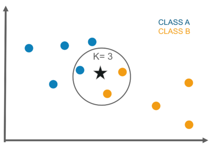

## *How does the KNN algorithm work?*

*In KNN, K is the number of nearest neighbors. The number of neighbors is the core deciding factor. K is generally an odd number if the number of classes is 2. When K=1, then the algorithm is known as the nearest neighbor algorithm. This is the simplest case. Suppose P1 is the point, for which label needs to predict. First, you find the one closest point to P1 and then the label of the nearest point assigned to P1.*

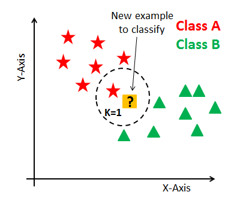

*Suppose P1 is the point, for which label needs to predict. First, you find the k closest point to P1 and then classify points by majority vote of its k neighbors. Each object votes for their class and the class with the most votes is taken as the prediction. For finding closest similar points, you find the distance between points using distance measures such as Euclidean distance, Hamming distance, Manhattan distance and Minkowski distance. KNN has the following basic steps:*

- *Calculate distance*
- *Find closest neighbors*
- *Vote for labels*

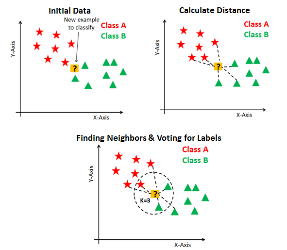

## *Eager Vs. Lazy Learners*

*Eager learners mean when given training points will construct a generalized model before performing prediction on given new points to classify. You can think of such learners as being ready, active and eager to classify unobserved data points.*

*Lazy Learning means there is no need for learning or training of the model and all of the data points used at the time of prediction. Lazy learners wait until the last minute before classifying any data point. Lazy learner stores merely the training dataset and waits until classification needs to perform. Only when it sees the test tuple does it perform generalization to classify the tuple based on its similarity to the stored training tuples. Unlike eager learning methods, lazy learners do less work in the training phase and more work in the testing phase to make a classification. Lazy learners are also known as instance-based learners because lazy learners store the training points or instances, and all learning is based on instances.*

## *Curse of Dimensionality*

*KNN performs better with a lower number of features than a large number of features. You can say that when the number of features increases than it requires more data. Increase in dimension also leads to the problem of overfitting. To avoid overfitting, the needed data will need to grow exponentially as you increase the number of dimensions. This problem of higher dimension is known as the Curse of Dimensionality.*

*To deal with the problem of the curse of dimensionality, you need to perform principal component analysis before applying any machine learning algorithm, or you can also use feature selection approach. Research has shown that in large dimension Euclidean distance is not useful anymore. Therefore, you can prefer other measures such as cosine similarity, which get decidedly less affected by high dimension.*

## *How to find the k-Nearest Neighbors?*

*To find the nearest neighbors, Algorithm calculates the distance between the new data point and training data points. And then shortlist the points which are closer to the new data point. These shortlisted points are known as the nearest neighbors to the new data point. Now two question arises how to calculate the distance between points and how many (k) closer points to be shortlisted.*

*The most commonly used distance measures are **Euclidean** and **Manhattan** for **continuous value** prediction that is **regression** and **Hamming Distance** for **categorical or classification problems**.*

### *Euclidean Distance*

*Euclidean distance is calculated as the square root of the sum of the squared differences between a new point (X2) and an existing point (X1).*

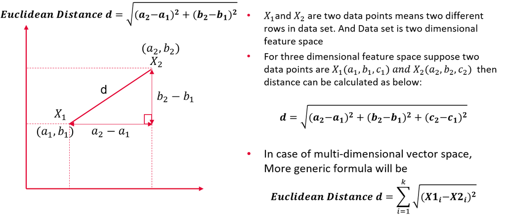

### *Manhattan Distance*

_This is the distance between real vectors using the sum of their absolute difference.__

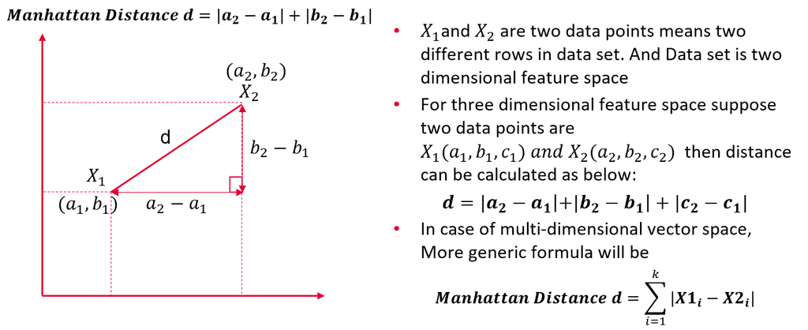

### **_Minkowski Distance__**

*Minkowski distance is a generalized distance metric. We can manipulate the above formula by substituting ‘p’ to calculate the distance between two data points in different ways. Thus, Minkowski Distance is also known as Lp norm distance.*

*Some common values of ‘p’ are:-*

- *p = 1, Manhattan Distance*
- *p = 2, Euclidean Distance*
- *p = infinity, Chebychev Distance*

_[Reference](https://medium.com/@kunal_gohrani/different-types-of-distance-metrics-used-in-machine-learning-e9928c5e26c7)_

### *Hamming Distance*

*It is used for categorical variables. If the value (x) and the value (y) are same, the distance D will be equal to 0 . Otherwise D=1.*

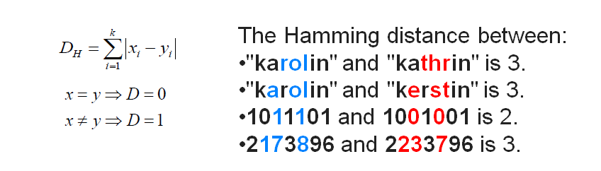

## *Deciding k – The hyper parameter in KNN*

*k is nothing but the number of nearest neighbors to be selected to finally predict the outcome of new data point. Decision of choosing the k is very important, although there is no mathematical formula to decide the k.*

- *There is no structured method to find the best value for “K”. We need to find out with various values by trial and error and assuming that training data is unknown.*
- *Choosing smaller values for K can be noisy and will have a higher influence on the result.*
- *Larger values of K will have smoother decision boundaries which mean lower variance but increased bias. Also, computationally expensive.*
- *Another way to choose K is though cross-validation. One way to select the cross-validation dataset from the training dataset. Take the small portion from the training dataset and call it a validation dataset, and then use the same to evaluate different possible values of K. This way we are going to predict the label for every instance in the validation set using with K equals to 1, K equals to 2, K equals to 3.. and then we look at what value of K gives us the best performance on the validation set and then we can take that value and use that as the final setting of our algorithm so we are minimizing the validation error.*
- *In general, practice, choosing the value of k is k = sqrt(N) where N stands for the number of samples in your training dataset.*
- *Try and keep the value of k odd in order to avoid confusion between two classes of data*

## *K-NN in Regression*

*In regression problems, K-NN is used for prediction based on the mean or the median of the K-most similar instances.*

## *K-NN in Classification*

*K-nearest-neighbor classification was actually developed from the need to perform discriminant analysis when reliable parametric estimates of probability densities are unknown or are difficult to determine. When K-NN is used for classification, the output is easily calculated by the class having the highest frequency from the K-most similar instances. The class with maximum vote is taken into consideration for prediction.*

*The probabilities of Classes can be calculated as the normalized frequency of samples that belong to each class in the set of K most similar instances for a new data instance.*

*For example, in a binary classification problem (class is 0 or 1):*

```
p(class=0) = count(class=0) / (count(class=0)+count(class=1))
```

*If you are using K and you have an even number of classes (e.g. 2) it is a good idea to choose a K value with an odd number to avoid a tie. And the inverse, use an even number for K when you have an odd number of classes.*

*Ties can be broken consistently by expanding K by 1 and looking at the class of the next most similar instance in the training dataset.*

## *How to improve the performance of K-NN?*

- *Rescaling Data:* *K-NN performs much better if all of the data has the same scale. Normalizing your data to the range [0, 1] is a good idea. It may also be a good idea to standardize your data if it has a Gaussian distribution.*
- *Addressing Missing Data:* *Missing data will mean that the distance between samples can not be calculated. These samples could be excluded or the missing values could be imputed.*
- *Reducing Dimensionality:* *K-NN is suited for lower dimensional data. You can try it on high dimensional data (hundreds or thousands of input variables) but be aware that it may not perform as good as other techniques. K-NN can benefit from feature selection that reduces the dimensionality of the input feature space.*

```python
# Packages / libraries

import os #provides functions for interacting with the operating system

import numpy as np
import pandas as pd
from matplotlib import pyplot as plt
import seaborn as sns

%matplotlib inline

import warnings
warnings.filterwarnings('ignore')
```

## *Classification Model*

```python
data_classification = pd.read_csv(r'C:\Users\PiyushSin\Desktop\datasets\UnivBank.csv', na_values = ('?','#','',' '))
```

```python
data_classification.head()
```

|  | ID | Age | Experience | Income | ZIP Code | Family | CCAvg | Education | Mortgage | Personal Loan | Securities Account | CD Account | Online | CreditCard |
| --- | --- | --- | --- | --- | --- | --- | --- | --- | --- | --- | --- | --- | --- | --- |
| 0 | 1 | 25 | 1 | 49 | 91107 | 4 | 1.6 | 1 | 0 | 0 | 1 | 0 | 0 | 0 |
| 1 | 2 | 45 | 19 | 34 | 90089 | 3 | 1.5 | 1 | 0 | 0 | 1 | 0 | 0 | 0 |
| 2 | 3 | 39 | 15 | 11 | 94720 | 1 | 1.0 | 1 | 0 | 0 | 0 | 0 | 0 | 0 |
| 3 | 4 | 35 | 9 | 100 | 94112 | 1 | 2.7 | 2 | 0 | 0 | 0 | 0 | 0 | 0 |
| 4 | 5 | 35 | 8 | 45 | 91330 | 4 | 1.0 | 2 | 0 | 0 | 0 | 0 | 0 | 1 |

```python
data_classification.tail()
```

|  | ID | Age | Experience | Income | ZIP Code | Family | CCAvg | Education | Mortgage | Personal Loan | Securities Account | CD Account | Online | CreditCard |
| --- | --- | --- | --- | --- | --- | --- | --- | --- | --- | --- | --- | --- | --- | --- |
| 4995 | 4996 | 29 | 3 | 40 | 92697 | 1 | 1.9 | 3 | 0 | 0 | 0 | 0 | 1 | 0 |
| 4996 | 4997 | 30 | 4 | 15 | 92037 | 4 | 0.4 | 1 | 85 | 0 | 0 | 0 | 1 | 0 |
| 4997 | 4998 | 63 | 39 | 24 | 93023 | 2 | 0.3 | 3 | 0 | 0 | 0 | 0 | 0 | 0 |
| 4998 | 4999 | 65 | 40 | 49 | 90034 | 3 | 0.5 | 2 | 0 | 0 | 0 | 0 | 1 | 0 |
| 4999 | 5000 | 28 | 4 | 83 | 92612 | 3 | 0.8 | 1 | 0 | 0 | 0 | 0 | 1 | 1 |

```python
data_classification.describe()
```

|  | ID | Age | Experience | Income | ZIP Code | Family | CCAvg | Education | Mortgage | Personal Loan | Securities Account | CD Account | Online | CreditCard |
| --- | --- | --- | --- | --- | --- | --- | --- | --- | --- | --- | --- | --- | --- | --- |
| count | 5000.000000 | 5000.000000 | 5000.000000 | 5000.000000 | 5000.000000 | 5000.000000 | 5000.000000 | 5000.000000 | 5000.000000 | 5000.000000 | 5000.000000 | 5000.00000 | 5000.000000 | 5000.000000 |
| mean | 2500.500000 | 45.338400 | 20.104600 | 73.774200 | 93152.503000 | 2.396400 | 1.937938 | 1.881000 | 56.498800 | 0.096000 | 0.104400 | 0.06040 | 0.596800 | 0.294000 |
| std | 1443.520003 | 11.463166 | 11.467954 | 46.033729 | 2121.852197 | 1.147663 | 1.747659 | 0.839869 | 101.713802 | 0.294621 | 0.305809 | 0.23825 | 0.490589 | 0.455637 |
| min | 1.000000 | 23.000000 | -3.000000 | 8.000000 | 9307.000000 | 1.000000 | 0.000000 | 1.000000 | 0.000000 | 0.000000 | 0.000000 | 0.00000 | 0.000000 | 0.000000 |
| 25% | 1250.750000 | 35.000000 | 10.000000 | 39.000000 | 91911.000000 | 1.000000 | 0.700000 | 1.000000 | 0.000000 | 0.000000 | 0.000000 | 0.00000 | 0.000000 | 0.000000 |
| 50% | 2500.500000 | 45.000000 | 20.000000 | 64.000000 | 93437.000000 | 2.000000 | 1.500000 | 2.000000 | 0.000000 | 0.000000 | 0.000000 | 0.00000 | 1.000000 | 0.000000 |
| 75% | 3750.250000 | 55.000000 | 30.000000 | 98.000000 | 94608.000000 | 3.000000 | 2.500000 | 3.000000 | 101.000000 | 0.000000 | 0.000000 | 0.00000 | 1.000000 | 1.000000 |
| max | 5000.000000 | 67.000000 | 43.000000 | 224.000000 | 96651.000000 | 4.000000 | 10.000000 | 3.000000 | 635.000000 | 1.000000 | 1.000000 | 1.00000 | 1.000000 | 1.000000 |

```python
from sklearn.model_selection import train_test_split

X = data_classification.drop('Personal Loan',axis=1).values
y = data_classification['Personal Loan'].values

X_train,X_test,y_train,y_test = train_test_split(X,y,test_size=0.4,random_state=42, stratify=y)
```

```python
from sklearn.neighbors import KNeighborsClassifier

neighbors = np.arange(1,15)
error = np.empty(len(neighbors))
train_accuracy = np.empty(len(neighbors))
test_accuracy = np.empty(len(neighbors))

for i,k in enumerate(neighbors):

    #Setup a knn classifier with k neighbors
    knn = KNeighborsClassifier(n_neighbors=k, p=2, metric='minkowski', n_jobs= -1)

    #Fit the model
    knn.fit(X_train, y_train)

    #Compute accuracy on the training set
    train_accuracy[i] = knn.score(X_train, y_train)

    #Compute accuracy on the test set
    test_accuracy[i] = knn.score(X_test, y_test)

    # get errors in predictions
    error[i] = np.mean(knn.predict(X_test) != y_test)
```

```python
train_accuracy
```

```
array([1.        , 0.922     , 0.92766667, 0.908     , 0.91133333,
       0.905     , 0.90566667, 0.90433333, 0.905     , 0.904     ,
       0.90433333, 0.904     , 0.904     , 0.904     ])
```

```python
test_accuracy
```

```
array([0.865 , 0.9   , 0.8955, 0.9035, 0.9015, 0.9035, 0.9035, 0.904 ,
       0.904 , 0.904 , 0.904 , 0.904 , 0.904 , 0.904 ])
```

```python
error
```

```
array([0.135 , 0.1   , 0.1045, 0.0965, 0.0985, 0.0965, 0.0965, 0.096 ,
       0.096 , 0.096 , 0.096 , 0.096 , 0.096 , 0.096 ])
```

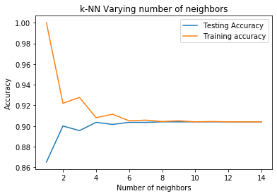

```python
# Scoring plot
plt.title('k-NN Varying number of neighbors')
plt.plot(neighbors, test_accuracy, label='Testing Accuracy')
plt.plot(neighbors, train_accuracy, label='Training accuracy')
plt.legend()
plt.xlabel('Number of neighbors')
plt.ylabel('Accuracy')
plt.show()
```

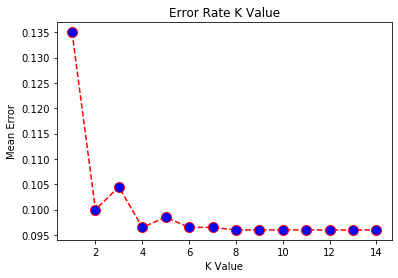

```python
# Error Plot

plt.plot(range(1, 15), error, color='red', linestyle='dashed', marker='o',
         markerfacecolor='blue', markersize=10)
plt.title('Error Rate K Value')
plt.xlabel('K Value')
plt.ylabel('Mean Error')
```

*we get maximum test accuracy for k = 8 and after that it is constant (Plot 1) and also the error is constant after k= 8 (Plot 2). Hence we will finalize k as 8 and train the model for 8 nearest neighbors.*

## *Multiclass Classification Model*

```python
from sklearn.datasets import load_wine

wine = load_wine()
```

```python
X = pd.DataFrame(wine.data, columns=wine.feature_names)
X.head()
```

|  | alcohol | malic_acid | ash | alcalinity_of_ash | magnesium | total_phenols | flavanoids | nonflavanoid_phenols | proanthocyanins | color_intensity | hue | od280/od315_of_diluted_wines | proline |
| --- | --- | --- | --- | --- | --- | --- | --- | --- | --- | --- | --- | --- | --- |
| 0 | 14.23 | 1.71 | 2.43 | 15.6 | 127.0 | 2.80 | 3.06 | 0.28 | 2.29 | 5.64 | 1.04 | 3.92 | 1065.0 |
| 1 | 13.20 | 1.78 | 2.14 | 11.2 | 100.0 | 2.65 | 2.76 | 0.26 | 1.28 | 4.38 | 1.05 | 3.40 | 1050.0 |
| 2 | 13.16 | 2.36 | 2.67 | 18.6 | 101.0 | 2.80 | 3.24 | 0.30 | 2.81 | 5.68 | 1.03 | 3.17 | 1185.0 |
| 3 | 14.37 | 1.95 | 2.50 | 16.8 | 113.0 | 3.85 | 3.49 | 0.24 | 2.18 | 7.80 | 0.86 | 3.45 | 1480.0 |
| 4 | 13.24 | 2.59 | 2.87 | 21.0 | 118.0 | 2.80 | 2.69 | 0.39 | 1.82 | 4.32 | 1.04 | 2.93 | 735.0 |

```python
y = wine.target
y
```

```
array([0, 0, 0, 0, 0, 0, 0, 0, 0, 0, 0, 0, 0, 0, 0, 0, 0, 0, 0, 0, 0, 0,
       0, 0, 0, 0, 0, 0, 0, 0, 0, 0, 0, 0, 0, 0, 0, 0, 0, 0, 0, 0, 0, 0,
       0, 0, 0, 0, 0, 0, 0, 0, 0, 0, 0, 0, 0, 0, 0, 1, 1, 1, 1, 1, 1, 1,
       1, 1, 1, 1, 1, 1, 1, 1, 1, 1, 1, 1, 1, 1, 1, 1, 1, 1, 1, 1, 1, 1,
       1, 1, 1, 1, 1, 1, 1, 1, 1, 1, 1, 1, 1, 1, 1, 1, 1, 1, 1, 1, 1, 1,
       1, 1, 1, 1, 1, 1, 1, 1, 1, 1, 1, 1, 1, 1, 1, 1, 1, 1, 1, 1, 2, 2,
       2, 2, 2, 2, 2, 2, 2, 2, 2, 2, 2, 2, 2, 2, 2, 2, 2, 2, 2, 2, 2, 2,
       2, 2, 2, 2, 2, 2, 2, 2, 2, 2, 2, 2, 2, 2, 2, 2, 2, 2, 2, 2, 2, 2,
       2, 2])
```

```python
from sklearn.preprocessing import StandardScaler
scaler = StandardScaler()
#fitting scaler to the feature
scaler.fit(X)
scaled_features = scaler.transform(X)
```

```python
df_feat = pd.DataFrame(scaled_features,columns=X.columns)
df_feat.head()
```

|  | alcohol | malic_acid | ash | alcalinity_of_ash | magnesium | total_phenols | flavanoids | nonflavanoid_phenols | proanthocyanins | color_intensity | hue | od280/od315_of_diluted_wines | proline |
| --- | --- | --- | --- | --- | --- | --- | --- | --- | --- | --- | --- | --- | --- |
| 0 | 1.518613 | -0.562250 | 0.232053 | -1.169593 | 1.913905 | 0.808997 | 1.034819 | -0.659563 | 1.224884 | 0.251717 | 0.362177 | 1.847920 | 1.013009 |
| 1 | 0.246290 | -0.499413 | -0.827996 | -2.490847 | 0.018145 | 0.568648 | 0.733629 | -0.820719 | -0.544721 | -0.293321 | 0.406051 | 1.113449 | 0.965242 |
| 2 | 0.196879 | 0.021231 | 1.109334 | -0.268738 | 0.088358 | 0.808997 | 1.215533 | -0.498407 | 2.135968 | 0.269020 | 0.318304 | 0.788587 | 1.395148 |
| 3 | 1.691550 | -0.346811 | 0.487926 | -0.809251 | 0.930918 | 2.491446 | 1.466525 | -0.981875 | 1.032155 | 1.186068 | -0.427544 | 1.184071 | 2.334574 |
| 4 | 0.295700 | 0.227694 | 1.840403 | 0.451946 | 1.281985 | 0.808997 | 0.663351 | 0.226796 | 0.401404 | -0.319276 | 0.362177 | 0.449601 | -0.037874 |

```python
from sklearn.model_selection import train_test_split
X_train, X_test, y_train, y_test = train_test_split(scaled_features,y, test_size=0.20)
```

```python
from sklearn.neighbors import KNeighborsClassifier
knn = KNeighborsClassifier(n_neighbors=5)
knn.fit(X_train, y_train)
```

```
KNeighborsClassifier()
```

```python
pred = knn.predict(X_test)
```

```python
from sklearn import metrics

print("Accuracy:",metrics.accuracy_score(y_test, pred))
```

```
Accuracy: 0.9722222222222222
```

```python
from sklearn.metrics import classification_report
print(classification_report(y_test,pred))
```

```
              precision    recall  f1-score   support

           0       1.00      1.00      1.00        10
           1       1.00      0.93      0.97        15
           2       0.92      1.00      0.96        11

    accuracy                           0.97        36
   macro avg       0.97      0.98      0.97        36
weighted avg       0.97      0.97      0.97        36
```

## *Custom Method for K-NN*

### *PseudoCode for k-NN*

*We can implement a KNN model by following the below steps:*

```python
class kNN():

    def __init__(self,n_neighbors):
        self.n_neighbors = n_neighbors
        self.distance = []
        self.index    = []

    def euclieanDist(self,train,test):
        sort = []
        for i in range(train.shape[0]):
            sort.append(np.sqrt(np.sum(np.square(train[i]-test))))
        return sort

    def fit(self,train,test):
        for x in range(test.shape[0]):
            dist = self.euclieanDist(train, test[x]) # all distance from test data to all training data
            idex = list(np.argsort(dist)[:self.n_neighbors]) # sortdata with argument and select top k points
            self.index.append(idex)
            temp = []
            for j in idex:
                temp.append(dist[j])
            self.distance.append(temp)

    def predict(self,y_train):
        y_cap = []
        for i in self.index:
            y_ = []
            for j in i:
                y_.append(y_train[j])
            y_cap.append(max(y_))
        return np.array(y_cap)

    def score(self,y_pred,y_actual):
        c=0
        for i in range(len(y_pred)):
            if y_pred[i] == y_actual[i]:
                c+=1
        return c/len(y_pred)
```

## *Regression Model*

```python
data = {'age':[25,35,45,20,35,52,23,40,60,48,33],
'loan':[40000,60000,80000,20000,120000,18000,95000,62000,100000,220000,150000],
'HPI':[135,256,231,269,139,150,127,216,139,250,264]}
```

```python
data_regression = pd.DataFrame(data)
```

```python
data_regression
```

|  | age | loan | HPI |
| --- | --- | --- | --- |
| 0 | 25 | 40000 | 135 |
| 1 | 35 | 60000 | 256 |
| 2 | 45 | 80000 | 231 |
| 3 | 20 | 20000 | 269 |
| 4 | 35 | 120000 | 139 |
| 5 | 52 | 18000 | 150 |
| 6 | 23 | 95000 | 127 |
| 7 | 40 | 62000 | 216 |
| 8 | 60 | 100000 | 139 |
| 9 | 48 | 220000 | 250 |
| 10 | 33 | 150000 | 264 |

```python
X= data_regression[['age','loan']]
y = data_regression['HPI']
```

```python
X
```

|  | age | loan |
| --- | --- | --- |
| 0 | 25 | 40000 |
| 1 | 35 | 60000 |
| 2 | 45 | 80000 |
| 3 | 20 | 20000 |
| 4 | 35 | 120000 |
| 5 | 52 | 18000 |
| 6 | 23 | 95000 |
| 7 | 40 | 62000 |
| 8 | 60 | 100000 |
| 9 | 48 | 220000 |
| 10 | 33 | 150000 |

```python
scaler = StandardScaler()
scaler.fit(X)
scaled_features = scaler.transform(X)
```

```python
scaled_features
```

```
array([[-1.06494739, -0.83618447],
       [-0.23413737, -0.48578336],
       [ 0.59667265, -0.13538225],
       [-1.4803524 , -1.18658558],
       [-0.23413737,  0.56541997],
       [ 1.17823967, -1.22162569],
       [-1.2311094 ,  0.12741859],
       [ 0.18126764, -0.45074325],
       [ 1.84288769,  0.21501886],
       [ 0.84591566,  2.31742552],
       [-0.40029937,  1.09102164]])
```

```python
from sklearn.model_selection import train_test_split
X_train, X_test, y_train, y_test = train_test_split(scaled_features,y, test_size=0.20)
```

```python
from sklearn.neighbors import KNeighborsRegressor
knn = KNeighborsRegressor(n_neighbors=1)
knn.fit(X_train, y_train)
```

```
KNeighborsRegressor(n_neighbors=1)
```

```python
pred = knn.predict(X_test)
```

```python
X_test
```

```
array([[-0.23413737, -0.48578336],
       [-0.23413737,  0.56541997],
       [-1.2311094 ,  0.12741859]])
```

```python
pred
```

```
array([216., 264., 135.])
```

## *Pros of KNN*

- *Training phase of K-nearest neighbor classification is faster in comparison with other classification algorithms.*
- *Training of a model is not required for generalization.*
- *Simple algorithm — to explain and understand/interpret.*
- *High accuracy (relatively) — it is pretty high but not competitive in comparison to better supervised learning models.*
- *K-NN can be useful in case of nonlinear data.*
- *Versatile — useful for classification or regression.*

## *Cons of KNN*

- *Testing phase of K-nearest neighbor classification is slower and costlier with respect to time and memory.*
- *High memory requirement - Requires large memory for storing the entire training dataset.*
- *K-NN requires scaling of data because K-NN uses the Euclidean distance between two data points to find nearest neighbors.*
- *Euclidean distance is sensitive to magnitudes. The features with high magnitudes will weigh more than features with low magnitudes.*
- *Not suitable for large dimensional data.*

## *Difference between KNN and K-Means?*

|  | k-NN | k-Means |
| --- | --- | --- |
| Types | Supervised | Unsupervised |
| What is K? | Number of closest neighbors to look at | Number of centroids |
| Calculation of prediction error possible | Yes | No |
| Optimization is done using what? | Cross-validation and confusion matrix | Elbow method and the silhouette method |
| Algorithm convergences | When all observations classified at the desired accuracy | When cluster membership doesn't change anymore |
| Complexity | Training: O(Dimensions/Features) Test: O (Number of Observations) | O (Number of points * Number of Clusters * Number of iterations * number of attributes) |

*[Reference](https://www.c-sharpcorner.com/article/knn-k-nearest-neighbors/)*